# Problem 1: Softmax MNIST Classification

For this question we are working with the MINST dataset for digit classification. Each image has the shape 1 x 28 x 28, the image is flattened into a 784 dimensional vector before being passed to the model

The model itself contains one linear layer with 784 input features and 10 output units (each output corresponding to one digit class). Model produces logits, which are converted into a classification loss using cross entropy

Trained with SGD for 200 epochs and a learning rate of 0.001 (this learning rate best reproduced the lecture slide example)

```python
import random
import numpy as np
import matplotlib.pyplot as plt

import torch
import torch.nn as nn
import torchvision
from torch.utils.data import DataLoader, TensorDataset
```

```python
seed = 42

random.seed(seed)
np.random.seed(seed)
torch.manual_seed(seed)

if torch.cuda.is_available():
    torch.cuda.manual_seed_all(seed)
```

```python
device = torch.device("cuda" if torch.cuda.is_available() else "cpu")
print("Using device:", device)
```

```
Using device: cuda
```

```python
transform = torchvision.transforms.Compose([
    torchvision.transforms.ToTensor(),
    torchvision.transforms.Normalize((0.1307,), (0.3081,))
])

mnist_train = torchvision.datasets.MNIST(
    root="./data",
    train=True,
    download=True,
    transform=transform
)

mnist_test = torchvision.datasets.MNIST(
    root="./data",
    train=False,
    download=True,
    transform=transform
)
```

```python
batch_size = 64

train_loader = DataLoader(
    mnist_train,
    batch_size=batch_size,
    shuffle=True
)

test_loader = DataLoader(
    mnist_test,
    batch_size=batch_size,
    shuffle=False
)
```

## Softmax Regression model

This model returns unnormalized logits which CrossEntropyLoss takes and applies the appropraite softmax based operation when calculating the loss

```python
class SoftmaxRegression(nn.Module):
    def __init__(self):
        super().__init__()
        self.linear = nn.Linear(28 * 28, 10)

        # Simple random initialization—not Xavier or Kaiming.
        nn.init.normal_(self.linear.weight, mean=0.0, std=0.01)
        nn.init.zeros_(self.linear.bias)

    def forward(self, x):
        x = x.view(x.size(0), -1)
        logits = self.linear(x)
        return logits
```

```python
model = SoftmaxRegression().to(device)
print(model)
```

```
SoftmaxRegression(
  (linear): Linear(in_features=784, out_features=10, bias=True)
)
```

```python
criterion = nn.CrossEntropyLoss()
```

```python
learning_rate = 0.001

optimizer = torch.optim.SGD(
    model.parameters(),
    lr=learning_rate
)
```

```python
num_epochs = 200

train_losses = []
test_accuracies = []

saved_weights = {}

for epoch in range(1, num_epochs + 1):

    # Training
    model.train()

    running_loss = 0.0
    total_training_examples = 0

    for images, labels in train_loader:
        images = images.to(device)
        labels = labels.to(device)

        optimizer.zero_grad()

        logits = model(images)

        loss = criterion(logits, labels)

        loss.backward()
        optimizer.step()

        batch_size = images.size(0)
        running_loss += loss.item() * batch_size
        total_training_examples += batch_size

    epoch_loss = running_loss / total_training_examples
    train_losses.append(epoch_loss)

    # Test evaluation
    model.eval()

    correct = 0
    total_test_examples = 0

    with torch.no_grad():
        for images, labels in test_loader:
            images = images.to(device)
            labels = labels.to(device)

            logits = model(images)
            predictions = logits.argmax(dim=1)

            correct += (predictions == labels).sum().item()
            total_test_examples += labels.size(0)

    test_accuracy = 100 * correct / total_test_examples
    test_accuracies.append(test_accuracy)

    if epoch in [20, 200]:
        saved_weights[epoch] = (
            model.linear.weight.detach().cpu().clone()
        )

    if epoch == 1 or epoch % 10 == 0:
        print(
            f"Epoch [{epoch:3d}/{num_epochs}] "
            f"Loss: {epoch_loss:.4f} "
            f"Test Accuracy: {test_accuracy:.2f}%"
        )
```

```
Epoch [  1/200] Loss: 0.9498 Test Accuracy: 86.87%
Epoch [ 10/200] Loss: 0.3479 Test Accuracy: 90.85%
Epoch [ 20/200] Loss: 0.3146 Test Accuracy: 91.46%
Epoch [ 30/200] Loss: 0.3002 Test Accuracy: 91.72%
Epoch [ 40/200] Loss: 0.2914 Test Accuracy: 91.85%
Epoch [ 50/200] Loss: 0.2855 Test Accuracy: 91.89%
Epoch [ 60/200] Loss: 0.2809 Test Accuracy: 91.97%
Epoch [ 70/200] Loss: 0.2774 Test Accuracy: 92.02%
Epoch [ 80/200] Loss: 0.2744 Test Accuracy: 92.12%
Epoch [ 90/200] Loss: 0.2719 Test Accuracy: 92.16%
Epoch [100/200] Loss: 0.2698 Test Accuracy: 92.16%
Epoch [110/200] Loss: 0.2678 Test Accuracy: 92.24%
Epoch [120/200] Loss: 0.2661 Test Accuracy: 92.29%
Epoch [130/200] Loss: 0.2647 Test Accuracy: 92.19%
Epoch [140/200] Loss: 0.2633 Test Accuracy: 92.27%
Epoch [150/200] Loss: 0.2620 Test Accuracy: 92.26%
Epoch [160/200] Loss: 0.2609 Test Accuracy: 92.33%
Epoch [170/200] Loss: 0.2598 Test Accuracy: 92.34%
Epoch [180/200] Loss: 0.2588 Test Accuracy: 92.32%
Epoch [190/200] Loss: 0.2579 Test Accuracy: 92.37%
Epoch [200/200] Loss: 0.2570 Test Accuracy: 92.39%
```

## Plotting M02-S09 Visualization

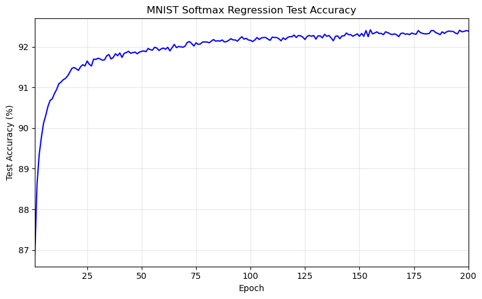

```python
epochs = range(1, len(test_accuracies) + 1)

plt.figure(figsize=(8, 5))
plt.plot(epochs, test_accuracies, color="blue", linewidth=1.5)

plt.xlabel("Epoch")
plt.ylabel("Test Accuracy (%)")
plt.title("MNIST Softmax Regression Test Accuracy")
plt.grid(True, alpha=0.3)
plt.xlim(1, len(test_accuracies))

plt.tight_layout()
plt.show()
```

As you can see, the test accuracy inreases fast during the first part of training then gradually plateaus after ~25 epoch, which matches the expected behavior shown on the lecture slides

```python
def plot_weights(weights, epoch):
    weight_images = weights.reshape(10, 28, 28)

    max_abs_weight = weight_images.abs().max().item()

    fig, axes = plt.subplots(2, 5, figsize=(12, 5))

    for digit, ax in enumerate(axes.flat):
        image = ax.imshow(
            weight_images[digit],
            cmap="seismic",
            vmin=-max_abs_weight,
            vmax=max_abs_weight
        )

        ax.set_title(f"Digit {digit}")
        ax.axis("off")

    fig.suptitle(
        f"Softmax Regression Weights at Epoch {epoch}",
        fontsize=14
    )

    fig.colorbar(
        image,
        ax=axes.ravel().tolist(),
        shrink=0.8,
        label="Weight Value"
    )

    plt.show()
```

## Plotting weight visualizations

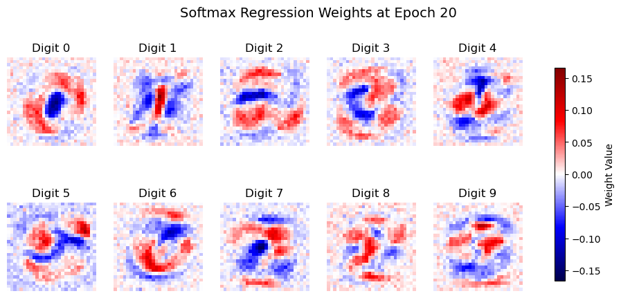

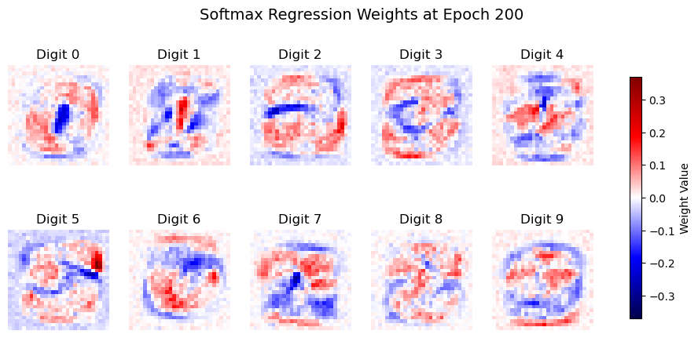

```python
plot_weights(saved_weights[20], 20)
plot_weights(saved_weights[200], 200)
```

This visualization shows which pixel regions contribute to each digit class, either positively or negatively

# Problem 2 - Autoencoders

In this problem I train two auto encoderes using the MINST images. One is a naive autoencoder trained only with reconstruction loss. The second is a sparse auto encoder with reconstruction + an additional KL divergence sparisty penalty for the loss

For the data definition, I created new tensors different from problem 1 because in the first question we used normalized images, but the AE needs pixel values between 0 and 1 as the decoder uses a sigmoid output and binary cross entropy loss

```python
ae_transform = torchvision.transforms.ToTensor()

mnist_train_ae = torchvision.datasets.MNIST(
    root="./data",
    train=True,
    download=True,
    transform=ae_transform
)

mnist_test_ae = torchvision.datasets.MNIST(
    root="./data",
    train=False,
    download=True,
    transform=ae_transform
)
```

```python
batch_size = 256

train_loader_ae = DataLoader(
    mnist_train_ae,
    batch_size=batch_size,
    shuffle=True
)

test_loader_ae = DataLoader(
    mnist_test_ae,
    batch_size=batch_size,
    shuffle=False
)
```

```python
class Autoencoder(nn.Module):
    def __init__(self):
        super().__init__()

        self.encoder = nn.Linear(28 * 28, 100)
        self.decoder = nn.Linear(100, 28 * 28)

        nn.init.normal_(self.encoder.weight, mean=0.0, std=0.01)
        nn.init.zeros_(self.encoder.bias)

        nn.init.normal_(self.decoder.weight, mean=0.0, std=0.01)
        nn.init.zeros_(self.decoder.bias)

    def encode(self, x):
        x = x.view(x.size(0), -1)
        hidden = torch.sigmoid(self.encoder(x))
        return hidden

    def decode(self, hidden):
        reconstruction = torch.sigmoid(self.decoder(hidden))
        return reconstruction

    def forward(self, x):
        hidden = self.encode(x)
        reconstruction = self.decode(hidden)

        return reconstruction, hidden
```

```python
reconstruction_criterion = nn.BCELoss(reduction="sum")
```

```python
def sparsity_kl_divergence(hidden, alpha=0.2):
    average_activation = hidden.mean(dim=0)
    epsilon = 1e-8
    average_activation = torch.clamp(average_activation, epsilon, 1 - epsilon)

    kl_divergence = (
        alpha * torch.log(alpha / average_activation)
        + (1 - alpha)
        * torch.log((1 - alpha) / (1 - average_activation))
    )

    return kl_divergence.sum()
```

```python
torch.manual_seed(42)
naive_autoencoder = Autoencoder().to(device)

torch.manual_seed(42)
sparse_autoencoder = Autoencoder().to(device)
```

```python
ae_learning_rate = 0.001

naive_optimizer = torch.optim.SGD(
    naive_autoencoder.parameters(),
    lr=ae_learning_rate
)

sparse_optimizer = torch.optim.SGD(
    sparse_autoencoder.parameters(),
    lr=ae_learning_rate
)
```

```python
alpha = 0.2
sparsity_weight = 0.1
```

```python
num_ae_epochs = 200

naive_losses = []
sparse_reconstruction_losses = []
sparse_total_losses = []
sparse_average_activations = []

for epoch in range(1, num_ae_epochs + 1):
    naive_autoencoder.train()
    sparse_autoencoder.train()

    naive_running_loss = 0.0
    sparse_reconstruction_running = 0.0
    sparse_total_running = 0.0

    total_examples = 0
    activation_sum = 0.0

    for images, _ in train_loader_ae:
        images = images.to(device)
        flat_images = images.view(images.size(0), -1)
        current_batch_size = images.size(0)

        # Train naïve autoencoder
        naive_optimizer.zero_grad()

        naive_reconstruction, _ = naive_autoencoder(images)

        naive_loss = reconstruction_criterion(naive_reconstruction, flat_images) / current_batch_size

        naive_loss.backward()
        naive_optimizer.step()

        # Train sparse autoencoder
        sparse_optimizer.zero_grad()

        sparse_reconstruction, sparse_hidden = (sparse_autoencoder(images))
        sparse_reconstruction_loss = reconstruction_criterion(sparse_reconstruction, flat_images) / current_batch_size

        sparsity_loss = sparsity_kl_divergence(sparse_hidden,alpha=alpha)
        sparse_total_loss = (sparse_reconstruction_loss + sparsity_weight * sparsity_loss)

        sparse_total_loss.backward()
        sparse_optimizer.step()

        # Record batch results
        naive_running_loss += (naive_loss.item() * current_batch_size)
        sparse_reconstruction_running += (sparse_reconstruction_loss.item() * current_batch_size)
        sparse_total_running += (sparse_total_loss.item() * current_batch_size)

        activation_sum += sparse_hidden.detach().sum().item()
        total_examples += current_batch_size

    naive_epoch_loss = naive_running_loss / total_examples
    sparse_reconstruction_epoch_loss = sparse_reconstruction_running / total_examples
    sparse_total_epoch_loss = sparse_total_running / total_examples

    sparse_epoch_activation = (activation_sum / (total_examples * 100))

    naive_losses.append(naive_epoch_loss)
    sparse_reconstruction_losses.append(sparse_reconstruction_epoch_loss)
    sparse_total_losses.append(sparse_total_epoch_loss)
    sparse_average_activations.append(sparse_epoch_activation)

    if epoch == 1 or epoch % 5 == 0:
        print(
            f"Epoch [{epoch:2d}/{num_ae_epochs}] | "
            f"Naive reconstruction: {naive_epoch_loss:.4f} | "
            f"Sparse reconstruction: "
            f"{sparse_reconstruction_epoch_loss:.4f} | "
            f"Sparse total: {sparse_total_epoch_loss:.4f} | "
            f"Mean activation: {sparse_epoch_activation:.4f}"
        )
```

```
Epoch [ 1/200] | Naive reconstruction: 314.4585 | Sparse reconstruction: 317.0559 | Sparse total: 323.5459 | Mean activation: 0.7209
Epoch [ 5/200] | Naive reconstruction: 209.7904 | Sparse reconstruction: 211.2604 | Sparse total: 220.0538 | Mean activation: 0.8117
Epoch [10/200] | Naive reconstruction: 207.7370 | Sparse reconstruction: 206.9072 | Sparse total: 212.3026 | Mean activation: 0.7003
Epoch [15/200] | Naive reconstruction: 207.1064 | Sparse reconstruction: 202.3656 | Sparse total: 206.7878 | Mean activation: 0.6476
Epoch [20/200] | Naive reconstruction: 206.7517 | Sparse reconstruction: 195.2298 | Sparse total: 198.9735 | Mean activation: 0.6075
Epoch [25/200] | Naive reconstruction: 206.4210 | Sparse reconstruction: 185.9102 | Sparse total: 188.9843 | Mean activation: 0.5731
Epoch [30/200] | Naive reconstruction: 205.3416 | Sparse reconstruction: 176.5790 | Sparse total: 179.2510 | Mean activation: 0.5504
Epoch [35/200] | Naive reconstruction: 202.0881 | Sparse reconstruction: 169.2434 | Sparse total: 171.7109 | Mean activation: 0.5371
Epoch [40/200] | Naive reconstruction: 198.1137 | Sparse reconstruction: 163.5585 | Sparse total: 165.9053 | Mean activation: 0.5282
Epoch [45/200] | Naive reconstruction: 194.8411 | Sparse reconstruction: 158.8473 | Sparse total: 161.1055 | Mean activation: 0.5211
Epoch [50/200] | Naive reconstruction: 192.1291 | Sparse reconstruction: 154.7620 | Sparse total: 156.9488 | Mean activation: 0.5153
Epoch [55/200] | Naive reconstruction: 189.0650 | Sparse reconstruction: 151.2031 | Sparse total: 153.3293 | Mean activation: 0.5103
Epoch [60/200] | Naive reconstruction: 185.2165 | Sparse reconstruction: 148.1038 | Sparse total: 150.1784 | Mean activation: 0.5059
Epoch [65/200] | Naive reconstruction: 180.7357 | Sparse reconstruction: 145.3606 | Sparse total: 147.3921 | Mean activation: 0.5021
Epoch [70/200] | Naive reconstruction: 176.1209 | Sparse reconstruction: 142.8798 | Sparse total: 144.8725 | Mean activation: 0.4988
Epoch [75/200] | Naive reconstruction: 171.8033 | Sparse reconstruction: 140.5992 | Sparse total: 142.5563 | Mean activation: 0.4956
Epoch [80/200] | Naive reconstruction: 167.9770 | Sparse reconstruction: 138.4842 | Sparse total: 140.4086 | Mean activation: 0.4928
Epoch [85/200] | Naive reconstruction: 164.6508 | Sparse reconstruction: 136.5124 | Sparse total: 138.4068 | Mean activation: 0.4901
Epoch [90/200] | Naive reconstruction: 161.7433 | Sparse reconstruction: 134.6594 | Sparse total: 136.5247 | Mean activation: 0.4875
Epoch [95/200] | Naive reconstruction: 159.1573 | Sparse reconstruction: 132.9016 | Sparse total: 134.7421 | Mean activation: 0.4852
Epoch [100/200] | Naive reconstruction: 156.8236 | Sparse reconstruction: 131.2219 | Sparse total: 133.0376 | Mean activation: 0.4829
Epoch [105/200] | Naive reconstruction: 154.6929 | Sparse reconstruction: 129.6079 | Sparse total: 131.4005 | Mean activation: 0.4808
Epoch [110/200] | Naive reconstruction: 152.7248 | Sparse reconstruction: 128.0537 | Sparse total: 129.8241 | Mean activation: 0.4788
Epoch [115/200] | Naive reconstruction: 150.8819 | Sparse reconstruction: 126.5548 | Sparse total: 128.3054 | Mean activation: 0.4770
Epoch [120/200] | Naive reconstruction: 149.1320 | Sparse reconstruction: 125.1092 | Sparse total: 126.8428 | Mean activation: 0.4754
Epoch [125/200] | Naive reconstruction: 147.4482 | Sparse reconstruction: 123.7158 | Sparse total: 125.4321 | Mean activation: 0.4739
Epoch [130/200] | Naive reconstruction: 145.8144 | Sparse reconstruction: 122.3716 | Sparse total: 124.0722 | Mean activation: 0.4725
Epoch [135/200] | Naive reconstruction: 144.2233 | Sparse reconstruction: 121.0730 | Sparse total: 122.7602 | Mean activation: 0.4714
Epoch [140/200] | Naive reconstruction: 142.6767 | Sparse reconstruction: 119.8186 | Sparse total: 121.4931 | Mean activation: 0.4702
Epoch [145/200] | Naive reconstruction: 141.1779 | Sparse reconstruction: 118.6043 | Sparse total: 120.2677 | Mean activation: 0.4692
Epoch [150/200] | Naive reconstruction: 139.7291 | Sparse reconstruction: 117.4308 | Sparse total: 119.0826 | Mean activation: 0.4683
Epoch [155/200] | Naive reconstruction: 138.3302 | Sparse reconstruction: 116.2957 | Sparse total: 117.9375 | Mean activation: 0.4674
Epoch [160/200] | Naive reconstruction: 136.9781 | Sparse reconstruction: 115.1990 | Sparse total: 116.8313 | Mean activation: 0.4667
Epoch [165/200] | Naive reconstruction: 135.6679 | Sparse reconstruction: 114.1409 | Sparse total: 115.7650 | Mean activation: 0.4660
Epoch [170/200] | Naive reconstruction: 134.3969 | Sparse reconstruction: 113.1205 | Sparse total: 114.7373 | Mean activation: 0.4654
Epoch [175/200] | Naive reconstruction: 133.1614 | Sparse reconstruction: 112.1378 | Sparse total: 113.7475 | Mean activation: 0.4648
Epoch [180/200] | Naive reconstruction: 131.9597 | Sparse reconstruction: 111.1919 | Sparse total: 112.7942 | Mean activation: 0.4642
Epoch [185/200] | Naive reconstruction: 130.7901 | Sparse reconstruction: 110.2799 | Sparse total: 111.8756 | Mean activation: 0.4637
Epoch [190/200] | Naive reconstruction: 129.6510 | Sparse reconstruction: 109.4009 | Sparse total: 110.9907 | Mean activation: 0.4633
Epoch [195/200] | Naive reconstruction: 128.5412 | Sparse reconstruction: 108.5536 | Sparse total: 110.1381 | Mean activation: 0.4629
Epoch [200/200] | Naive reconstruction: 127.4588 | Sparse reconstruction: 107.7352 | Sparse total: 109.3146 | Mean activation: 0.4625
```

Encoder weights are reshaped from vectors with length 784 back into the 28 x 28 images so the learned feature patterns can be visualized

## Plotting M02-S11 Weight Visualization

```python
def plot_encoder_weights(model, title):
    weights = model.encoder.weight.detach().cpu()

    fig, axes = plt.subplots(5, 5, figsize=(8, 8))

    for feature_index, ax in enumerate(axes.flat):
        weight_image = weights[feature_index].view(28, 28)

        ax.imshow(weight_image, cmap="viridis")
        ax.axis("off")

    fig.suptitle(title, fontsize=14)
    plt.tight_layout()
    plt.show()
```

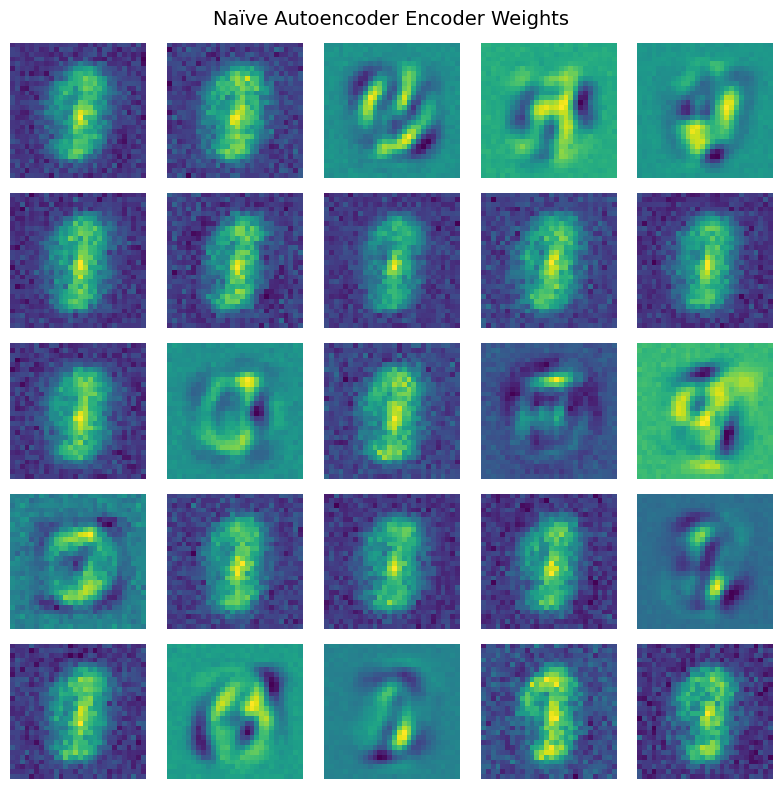

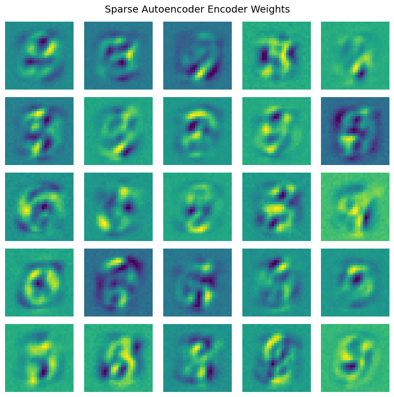

```python
plot_encoder_weights(
    naive_autoencoder,
    "Naïve Autoencoder Encoder Weights"
)

plot_encoder_weights(
    sparse_autoencoder,
    "Sparse Autoencoder Encoder Weights"
)
```

```python
def plot_reconstruction_grid(model, test_loader, device, title, num_images=25):
    model.eval()

    images, _ = next(iter(test_loader))
    images = images[:num_images].to(device)

    with torch.no_grad():
        reconstructions, _ = model(images)

    reconstructions = reconstructions.cpu().view(-1, 28, 28)

    fig, axes = plt.subplots(5, 5,figsize=(5, 5))

    for index, ax in enumerate(axes.flat):
        ax.imshow(
            reconstructions[index],
            cmap="viridis",
            vmin=0,
            vmax=1
        )
        ax.axis("off")

    fig.suptitle(title, fontsize=13)
    plt.subplots_adjust(wspace=0.08, hspace=0.08, top=0.90)
    plt.show()
```

## Plottting M02-S11 Reconstruction Visualization

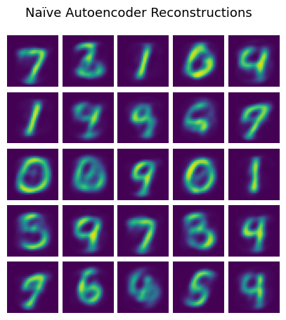

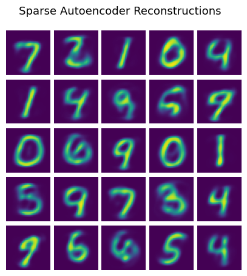

```python
plot_reconstruction_grid(
    naive_autoencoder,
    test_loader_ae,
    device,
    "Naïve Autoencoder Reconstructions"
)

plot_reconstruction_grid(
    sparse_autoencoder,
    test_loader_ae,
    device,
    "Sparse Autoencoder Reconstructions"
)
```

```python
def collect_hidden_activations(model, data_loader, device, num_images=150):
    model.eval()
    collected_activations = []

    with torch.no_grad():
        for images, _ in data_loader:
            images = images.to(device)
            hidden = model.encode(images)

            collected_activations.append(hidden.cpu())
            total_collected = sum(batch.size(0) for batch in collected_activations)

            if total_collected >= num_images:
                break

    activations = torch.cat(collected_activations, dim=0)

    return activations[:num_images]
```

```python
naive_activations = collect_hidden_activations(
    naive_autoencoder,
    test_loader_ae,
    device
)

sparse_activations = collect_hidden_activations(
    sparse_autoencoder,
    test_loader_ae,
    device
)
```

## Plotting M02-S11 Hidden unit activation visualizatoins

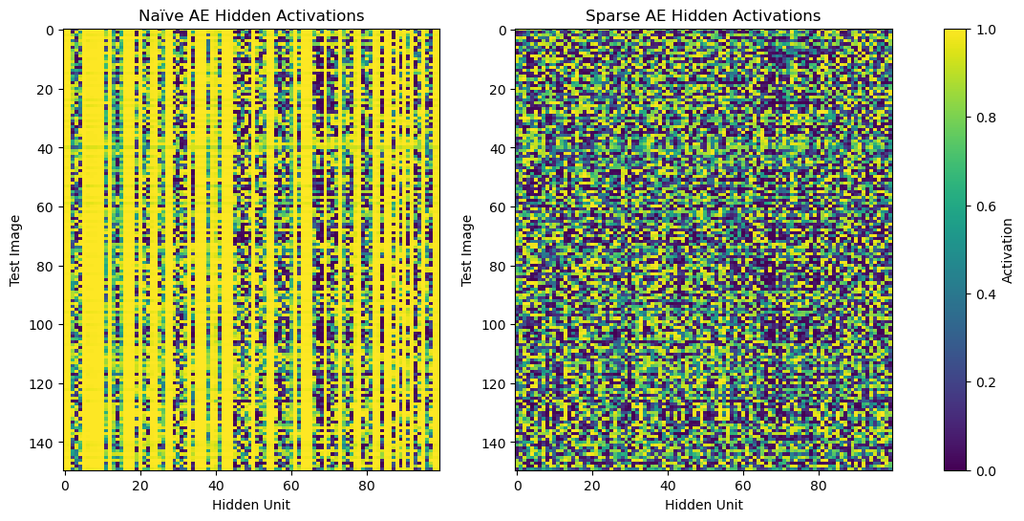

```python
fig, axes = plt.subplots(1, 2, figsize=(14, 6))

axes[0].imshow(
    naive_activations,
    aspect="auto",
    cmap="viridis",
    vmin=0,
    vmax=1
)

axes[0].set_title("Naïve AE Hidden Activations")
axes[0].set_xlabel("Hidden Unit")
axes[0].set_ylabel("Test Image")

activation_plot = axes[1].imshow(
    sparse_activations,
    aspect="auto",
    cmap="viridis",
    vmin=0,
    vmax=1
)

axes[1].set_title("Sparse AE Hidden Activations")
axes[1].set_xlabel("Hidden Unit")
axes[1].set_ylabel("Test Image")

fig.colorbar(
    activation_plot,
    ax=axes,
    label="Activation"
)

plt.show()
```

```python
feature_train_loader = DataLoader(
    mnist_train_ae,
    batch_size=256,
    shuffle=False
)
```

Now that I have the auto encoders trained, I can use each one to transform the MINST images into a 100 dimensional feature vector. These parameters are not updated during the classifiation training.

```python
def extract_features(model, data_loader, device):
    model.eval()

    all_features = []
    all_labels = []

    with torch.no_grad():
        for images, labels in data_loader:
            images = images.to(device)

            features = model.encode(images)

            all_features.append(features.cpu())
            all_labels.append(labels)

    return (torch.cat(all_features, dim=0), torch.cat(all_labels, dim=0))
```

```python
naive_train_features, train_labels = extract_features(naive_autoencoder, feature_train_loader,device)
naive_test_features, test_labels = extract_features(naive_autoencoder, test_loader_ae,device)

sparse_train_features, sparse_train_labels = extract_features(sparse_autoencoder, feature_train_loader,device)
sparse_test_features, sparse_test_labels = extract_features(sparse_autoencoder, test_loader_ae,device)
```

```python
raw_train_features = mnist_train_ae.data.float().view(-1, 28 * 28)/ 255.0
raw_test_features = mnist_test_ae.data.float().view(-1, 28 * 28) / 255.0

raw_train_labels = mnist_train_ae.targets
raw_test_labels = mnist_test_ae.targets
```

```python
naive_train_dataset = TensorDataset(naive_train_features, train_labels)
naive_test_dataset = TensorDataset(naive_test_features, test_labels)

sparse_train_dataset = TensorDataset(sparse_train_features,train_labels)
sparse_test_dataset = TensorDataset(sparse_test_features,test_labels)
```

```python
raw_train_dataset = TensorDataset(raw_train_features, raw_train_labels)
raw_test_dataset = TensorDataset(raw_test_features, raw_test_labels)

raw_classifier_train_loader = DataLoader(raw_train_dataset, batch_size=256, shuffle=True)
raw_classifier_test_loader = DataLoader(raw_test_dataset, batch_size=256,shuffle=False)
```

```python
classifier_batch_size = 256

naive_classifier_train_loader = DataLoader(naive_train_dataset, batch_size=classifier_batch_size, shuffle=True)
naive_classifier_test_loader = DataLoader(naive_test_dataset, batch_size=classifier_batch_size, shuffle=False)

sparse_classifier_train_loader = DataLoader(sparse_train_dataset, batch_size=classifier_batch_size, shuffle=True)
sparse_classifier_test_loader = DataLoader(sparse_test_dataset, batch_size=classifier_batch_size,shuffle=False)
```

This feature classifier maps the 100-dimensional autoencoder representation directly to the 10 digit classes.

```python
class FeatureClassifier(nn.Module):
    def __init__(self):
        super().__init__()

        self.linear = nn.Linear(100, 10)

        nn.init.normal_(self.linear.weight, mean=0.0, std=0.01)
        nn.init.zeros_(self.linear.bias)

    def forward(self, features):
        logits = self.linear(features)
        return logits
```

This raw-pixel classifier instead maps the original 784-dimensional image directly to the 10 classes, for the no feature baseline.

```python
class RawPixelClassifier(nn.Module):
    def __init__(self):
        super().__init__()

        self.linear = nn.Linear(28 * 28, 10)

        nn.init.normal_(self.linear.weight, mean=0.0, std=0.01)
        nn.init.zeros_(self.linear.bias)

    def forward(self, pixels):
        return self.linear(pixels)
```

```python
torch.manual_seed(42)
naive_classifier = FeatureClassifier().to(device)

torch.manual_seed(42)
sparse_classifier = FeatureClassifier().to(device)

torch.manual_seed(42)
raw_classifier = RawPixelClassifier().to(device)
```

```python
classification_criterion = nn.CrossEntropyLoss()

classifier_learning_rate = 0.1

naive_classifier_optimizer = torch.optim.SGD(
    naive_classifier.parameters(),
    lr=classifier_learning_rate
)

sparse_classifier_optimizer = torch.optim.SGD(
    sparse_classifier.parameters(),
    lr=classifier_learning_rate
)

raw_classifier_optimizer = torch.optim.SGD(
    raw_classifier.parameters(),
    lr=classifier_learning_rate
)
```

```python
def train_feature_classifier(model,train_loader, test_loader, optimizer, criterion, device, num_epochs=200):
    test_accuracies = []

    for epoch in range(1, num_epochs + 1):
        model.train()

        for features, labels in train_loader:
            features = features.to(device)
            labels = labels.to(device)

            optimizer.zero_grad()

            logits = model(features)
            loss = criterion(logits, labels)

            loss.backward()
            optimizer.step()

        model.eval()

        correct = 0
        total = 0

        with torch.no_grad():
            for features, labels in test_loader:
                features = features.to(device)
                labels = labels.to(device)

                logits = model(features)
                predictions = logits.argmax(dim=1)

                correct += (
                    predictions == labels
                ).sum().item()

                total += labels.size(0)

        test_accuracy = 100 * correct / total
        test_accuracies.append(test_accuracy)

        if epoch == 1 or epoch % 10 == 0:
            print(
                f"Epoch [{epoch:3d}/{num_epochs}] "
                f"Test Accuracy: {test_accuracy:.2f}%"
            )

    return test_accuracies
```

```python
naive_test_accuracies = train_feature_classifier(
    naive_classifier,
    naive_classifier_train_loader,
    naive_classifier_test_loader,
    naive_classifier_optimizer,
    classification_criterion,
    device,
    num_epochs=200
)
```

```
Epoch [  1/200] Test Accuracy: 80.23%
Epoch [ 10/200] Test Accuracy: 86.53%
Epoch [ 20/200] Test Accuracy: 87.46%
Epoch [ 30/200] Test Accuracy: 88.22%
Epoch [ 40/200] Test Accuracy: 88.70%
Epoch [ 50/200] Test Accuracy: 88.96%
Epoch [ 60/200] Test Accuracy: 89.05%
Epoch [ 70/200] Test Accuracy: 89.19%
Epoch [ 80/200] Test Accuracy: 89.27%
Epoch [ 90/200] Test Accuracy: 89.30%
Epoch [100/200] Test Accuracy: 89.36%
Epoch [110/200] Test Accuracy: 89.43%
Epoch [120/200] Test Accuracy: 89.60%
Epoch [130/200] Test Accuracy: 89.56%
Epoch [140/200] Test Accuracy: 89.66%
Epoch [150/200] Test Accuracy: 89.64%
Epoch [160/200] Test Accuracy: 89.71%
Epoch [170/200] Test Accuracy: 89.76%
Epoch [180/200] Test Accuracy: 89.82%
Epoch [190/200] Test Accuracy: 89.84%
Epoch [200/200] Test Accuracy: 89.90%
```

```python
sparse_test_accuracies = train_feature_classifier(
    sparse_classifier,
    sparse_classifier_train_loader,
    sparse_classifier_test_loader,
    sparse_classifier_optimizer,
    classification_criterion,
    device,
    num_epochs=200
)
```

```
Epoch [  1/200] Test Accuracy: 85.57%
Epoch [ 10/200] Test Accuracy: 89.24%
Epoch [ 20/200] Test Accuracy: 90.13%
Epoch [ 30/200] Test Accuracy: 90.68%
Epoch [ 40/200] Test Accuracy: 90.89%
Epoch [ 50/200] Test Accuracy: 91.04%
Epoch [ 60/200] Test Accuracy: 91.23%
Epoch [ 70/200] Test Accuracy: 91.44%
Epoch [ 80/200] Test Accuracy: 91.50%
Epoch [ 90/200] Test Accuracy: 91.62%
Epoch [100/200] Test Accuracy: 91.65%
Epoch [110/200] Test Accuracy: 91.70%
Epoch [120/200] Test Accuracy: 91.76%
Epoch [130/200] Test Accuracy: 91.78%
Epoch [140/200] Test Accuracy: 91.73%
Epoch [150/200] Test Accuracy: 91.75%
Epoch [160/200] Test Accuracy: 91.99%
Epoch [170/200] Test Accuracy: 91.85%
Epoch [180/200] Test Accuracy: 91.97%
Epoch [190/200] Test Accuracy: 91.96%
Epoch [200/200] Test Accuracy: 92.02%
```

```python
raw_test_accuracies = train_feature_classifier(
    raw_classifier,
    raw_classifier_train_loader,
    raw_classifier_test_loader,
    raw_classifier_optimizer,
    classification_criterion,
    device,
    num_epochs=200
)
```

```
Epoch [  1/200] Test Accuracy: 89.03%
Epoch [ 10/200] Test Accuracy: 91.70%
Epoch [ 20/200] Test Accuracy: 92.09%
Epoch [ 30/200] Test Accuracy: 92.29%
Epoch [ 40/200] Test Accuracy: 92.15%
Epoch [ 50/200] Test Accuracy: 92.33%
Epoch [ 60/200] Test Accuracy: 92.39%
Epoch [ 70/200] Test Accuracy: 92.42%
Epoch [ 80/200] Test Accuracy: 92.46%
Epoch [ 90/200] Test Accuracy: 92.50%
Epoch [100/200] Test Accuracy: 92.54%
Epoch [110/200] Test Accuracy: 92.63%
Epoch [120/200] Test Accuracy: 92.45%
Epoch [130/200] Test Accuracy: 92.43%
Epoch [140/200] Test Accuracy: 92.53%
Epoch [150/200] Test Accuracy: 92.49%
Epoch [160/200] Test Accuracy: 92.65%
Epoch [170/200] Test Accuracy: 92.51%
Epoch [180/200] Test Accuracy: 92.63%
Epoch [190/200] Test Accuracy: 92.59%
Epoch [200/200] Test Accuracy: 92.61%
```

## Plotting M02-S12 Visualization

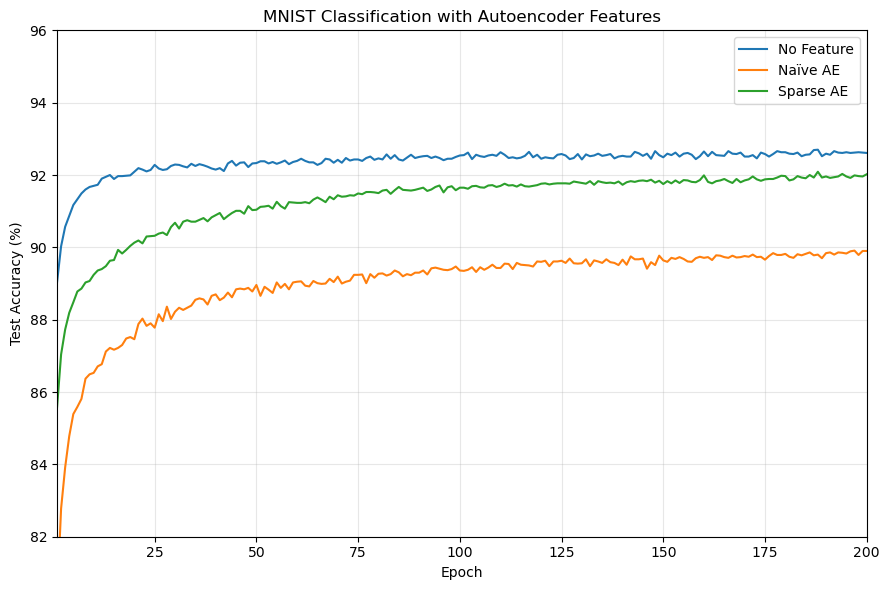

```python
epochs = range(1, 201)

plt.figure(figsize=(9, 6))

plt.plot(
    epochs,
    raw_test_accuracies,
    label="No Feature",
    linewidth=1.5
)

plt.plot(
    epochs,
    naive_test_accuracies,
    label="Naïve AE",
    linewidth=1.5
)

plt.plot(
    epochs,
    sparse_test_accuracies,
    label="Sparse AE",
    linewidth=1.5
)

plt.xlabel("Epoch")
plt.ylabel("Test Accuracy (%)")
plt.title("MNIST Classification with Autoencoder Features")

plt.xlim(1, 200)
plt.ylim(82, 96)

plt.grid(True, alpha=0.3)
plt.legend()

plt.tight_layout()
plt.show()
```

As you can see, the sparse AE outperformed the naïve AE as expected, but unfortunately I was not able to reproduce the sparse AE outperforming the raw-pixel classifier. This could be to differences in training duration, learning rate, initialization, or the scaling of the reconstruction and sparsity losses compared with the lecture implementation.

# Question 3 - A Shallow NN

For this question, I implemented a shallow NN with one hidden layer that has 100 hidden units. Unlike the previous auto encoder classifiers in question 2, both of these layers are trained with backpropagation using the digit classification loss

```python
class ShallowNN(nn.Module):
    def __init__(self):
        super().__init__()

        self.hidden = nn.Linear(28 * 28, 100)
        self.output = nn.Linear(100, 10)

        nn.init.normal_(self.hidden.weight, mean=0.0, std=0.01)
        nn.init.zeros_(self.hidden.bias)

        nn.init.normal_(self.output.weight, mean=0.0, std=0.01)
        nn.init.zeros_(self.output.bias)

    def forward(self, x):
        x = x.view(x.size(0), -1)
        hidden = torch.sigmoid(self.hidden(x))
        logits = self.output(hidden)

        return logits
```

```python
shallow_model = ShallowNN().to(device)

criterion = nn.CrossEntropyLoss()

shallow_optimizer = torch.optim.SGD(
    shallow_model.parameters(),
    lr=0.1
)
```

```python
num_epochs = 200
shallow_accuracies = []

for epoch in range(num_epochs):
    shallow_model.train()

    running_loss = 0.0

    for images, labels in train_loader:
        images = images.to(device)
        labels = labels.to(device)

        shallow_optimizer.zero_grad()

        logits = shallow_model(images)
        loss = criterion(logits, labels)

        loss.backward()
        shallow_optimizer.step()

        running_loss += loss.item()

    shallow_model.eval()

    correct = 0
    total = 0

    with torch.no_grad():
        for images, labels in test_loader:
            images = images.to(device)
            labels = labels.to(device)

            logits = shallow_model(images)
            predictions = logits.argmax(dim=1)

            correct += (predictions == labels).sum().item()
            total += labels.size(0)

    test_accuracy = 100 * correct / total
    shallow_accuracies.append(test_accuracy)

    if epoch == 0 or (epoch + 1) % 10 == 0:
        average_loss = running_loss / len(train_loader)

        print(
            f"Epoch [{epoch + 1:3d}/{num_epochs}] "
            f"Loss: {average_loss:.4f} "
            f"Test Accuracy: {test_accuracy:.2f}%"
        )
```

```
Epoch [  1/200] Loss: 0.6256 Test Accuracy: 91.73%
Epoch [ 10/200] Loss: 0.0934 Test Accuracy: 96.94%
Epoch [ 20/200] Loss: 0.0501 Test Accuracy: 97.53%
Epoch [ 30/200] Loss: 0.0313 Test Accuracy: 97.68%
Epoch [ 40/200] Loss: 0.0211 Test Accuracy: 97.73%
Epoch [ 50/200] Loss: 0.0151 Test Accuracy: 97.79%
Epoch [ 60/200] Loss: 0.0114 Test Accuracy: 97.76%
Epoch [ 70/200] Loss: 0.0089 Test Accuracy: 97.76%
Epoch [ 80/200] Loss: 0.0072 Test Accuracy: 97.79%
Epoch [ 90/200] Loss: 0.0060 Test Accuracy: 97.78%
Epoch [100/200] Loss: 0.0051 Test Accuracy: 97.74%
Epoch [110/200] Loss: 0.0044 Test Accuracy: 97.75%
Epoch [120/200] Loss: 0.0039 Test Accuracy: 97.77%
Epoch [130/200] Loss: 0.0035 Test Accuracy: 97.77%
Epoch [140/200] Loss: 0.0031 Test Accuracy: 97.77%
Epoch [150/200] Loss: 0.0028 Test Accuracy: 97.79%
Epoch [160/200] Loss: 0.0026 Test Accuracy: 97.80%
Epoch [170/200] Loss: 0.0024 Test Accuracy: 97.81%
Epoch [180/200] Loss: 0.0022 Test Accuracy: 97.80%
Epoch [190/200] Loss: 0.0021 Test Accuracy: 97.78%
Epoch [200/200] Loss: 0.0019 Test Accuracy: 97.79%
```

## Plotting M02-S14 Visualization

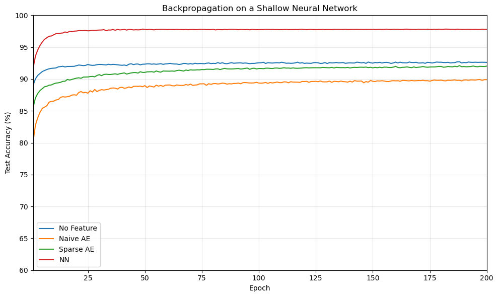

```python
epochs = range(1, 201)

plt.figure(figsize=(10, 6))

plt.plot(epochs, raw_test_accuracies, label="No Feature")
plt.plot(epochs, naive_test_accuracies, label="Naive AE")
plt.plot(epochs, sparse_test_accuracies, label="Sparse AE")
plt.plot(epochs, shallow_accuracies, label="NN")

plt.xlabel("Epoch")
plt.ylabel("Test Accuracy (%)")
plt.title("Backpropagation on a Shallow Neural Network")

plt.xlim(1, 200)
plt.ylim(60, 100)

plt.grid(True, alpha=0.3)
plt.legend()
plt.tight_layout()
plt.show()
```

The shallow NN performs better than the models that used fixed auto encoder features as expected. This shows that learning the hidden representation and classifier together allows the hidden layer to adapt directly to the digit classification loss

# Question 4

## Part 1

For this question, the learned auto encoder weights are used to initialize the first layer of a shallow NN. Unlike question 2, the first layer is not frozen, both the initialized feature layer and the output layer are updated together using backpropigation

```python
def initialize_shallow_from_autoencoder(autoencoder):
    model = ShallowNN().to(device)

    with torch.no_grad():
        model.hidden.weight.copy_(autoencoder.encoder.weight)
        model.hidden.bias.copy_(autoencoder.encoder.bias)

    return model


torch.manual_seed(42)
random_nn_s17 = ShallowNN().to(device)
naive_nn_s17 = initialize_shallow_from_autoencoder(naive_autoencoder)
sparse_nn_s17 = initialize_shallow_from_autoencoder(sparse_autoencoder)
```

```python
def train_shallow_network(model, train_loader, test_loader, num_epochs=200, learning_rate=0.1):
    criterion = nn.CrossEntropyLoss()

    optimizer = torch.optim.SGD(
        model.parameters(),
        lr=learning_rate
    )

    test_accuracies = []

    for epoch in range(1, num_epochs + 1):
        model.train()

        for images, labels in train_loader:
            images = images.to(device)
            labels = labels.to(device)

            optimizer.zero_grad()

            logits = model(images)
            loss = criterion(logits, labels)

            loss.backward()
            optimizer.step()

        model.eval()

        correct = 0
        total = 0

        with torch.no_grad():
            for images, labels in test_loader:
                images = images.to(device)
                labels = labels.to(device)

                logits = model(images)
                predictions = logits.argmax(dim=1)

                correct += (
                    predictions == labels
                ).sum().item()

                total += labels.size(0)

        accuracy = 100 * correct / total
        test_accuracies.append(accuracy)

        if epoch == 1 or epoch % 10 == 0:
            print(
                f"Epoch [{epoch:3d}/{num_epochs}] "
                f"Test Accuracy: {accuracy:.2f}%"
            )

    return test_accuracies
```

```python
random_nn_s17_accuracies = train_shallow_network(
    random_nn_s17,
    train_loader_ae,
    test_loader_ae
)
```

```
Epoch [  1/200] Test Accuracy: 51.80%
Epoch [ 10/200] Test Accuracy: 91.08%
Epoch [ 20/200] Test Accuracy: 92.73%
Epoch [ 30/200] Test Accuracy: 93.71%
Epoch [ 40/200] Test Accuracy: 94.65%
Epoch [ 50/200] Test Accuracy: 95.19%
Epoch [ 60/200] Test Accuracy: 95.57%
Epoch [ 70/200] Test Accuracy: 95.87%
Epoch [ 80/200] Test Accuracy: 96.21%
Epoch [ 90/200] Test Accuracy: 96.47%
Epoch [100/200] Test Accuracy: 96.66%
Epoch [110/200] Test Accuracy: 96.79%
Epoch [120/200] Test Accuracy: 96.86%
Epoch [130/200] Test Accuracy: 97.02%
Epoch [140/200] Test Accuracy: 97.13%
Epoch [150/200] Test Accuracy: 97.17%
Epoch [160/200] Test Accuracy: 97.24%
Epoch [170/200] Test Accuracy: 97.31%
Epoch [180/200] Test Accuracy: 97.36%
Epoch [190/200] Test Accuracy: 97.42%
Epoch [200/200] Test Accuracy: 97.50%
```

```python
naive_nn_s17_accuracies = train_shallow_network(
    naive_nn_s17,
    train_loader_ae,
    test_loader_ae
)
```

```
Epoch [  1/200] Test Accuracy: 82.62%
Epoch [ 10/200] Test Accuracy: 91.92%
Epoch [ 20/200] Test Accuracy: 93.77%
Epoch [ 30/200] Test Accuracy: 94.64%
Epoch [ 40/200] Test Accuracy: 95.12%
Epoch [ 50/200] Test Accuracy: 95.47%
Epoch [ 60/200] Test Accuracy: 95.75%
Epoch [ 70/200] Test Accuracy: 95.95%
Epoch [ 80/200] Test Accuracy: 96.14%
Epoch [ 90/200] Test Accuracy: 96.37%
Epoch [100/200] Test Accuracy: 96.42%
Epoch [110/200] Test Accuracy: 96.62%
Epoch [120/200] Test Accuracy: 96.61%
Epoch [130/200] Test Accuracy: 96.67%
Epoch [140/200] Test Accuracy: 96.80%
Epoch [150/200] Test Accuracy: 96.88%
Epoch [160/200] Test Accuracy: 96.85%
Epoch [170/200] Test Accuracy: 96.96%
Epoch [180/200] Test Accuracy: 96.97%
Epoch [190/200] Test Accuracy: 97.00%
Epoch [200/200] Test Accuracy: 97.03%
```

```python
sparse_nn_s17_accuracies = train_shallow_network(
    sparse_nn_s17,
    train_loader_ae,
    test_loader_ae
)
```

```
Epoch [  1/200] Test Accuracy: 86.39%
Epoch [ 10/200] Test Accuracy: 92.16%
Epoch [ 20/200] Test Accuracy: 93.69%
Epoch [ 30/200] Test Accuracy: 94.56%
Epoch [ 40/200] Test Accuracy: 95.06%
Epoch [ 50/200] Test Accuracy: 95.42%
Epoch [ 60/200] Test Accuracy: 95.74%
Epoch [ 70/200] Test Accuracy: 96.05%
Epoch [ 80/200] Test Accuracy: 96.46%
Epoch [ 90/200] Test Accuracy: 96.59%
Epoch [100/200] Test Accuracy: 96.74%
Epoch [110/200] Test Accuracy: 96.89%
Epoch [120/200] Test Accuracy: 97.00%
Epoch [130/200] Test Accuracy: 97.08%
Epoch [140/200] Test Accuracy: 97.20%
Epoch [150/200] Test Accuracy: 97.22%
Epoch [160/200] Test Accuracy: 97.27%
Epoch [170/200] Test Accuracy: 97.32%
Epoch [180/200] Test Accuracy: 97.34%
Epoch [190/200] Test Accuracy: 97.40%
Epoch [200/200] Test Accuracy: 97.42%
```

## Plotting M02-S17 Visualization

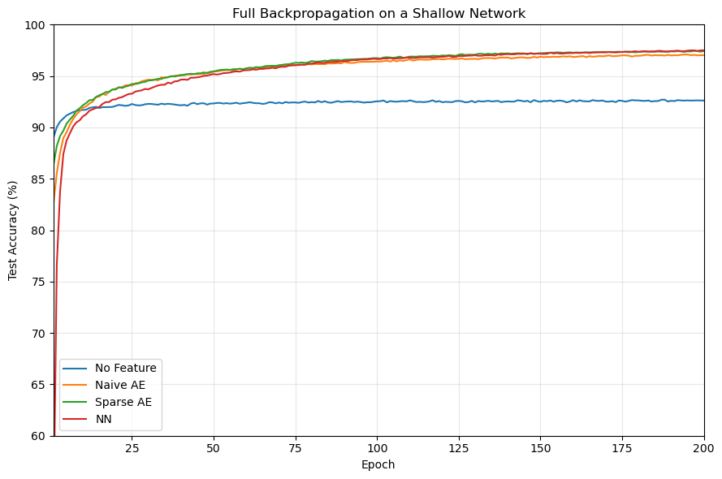

```python
epochs = range(1, 201)

plt.figure(figsize=(9, 6))

plt.plot(
    epochs,
    raw_test_accuracies,
    label="No Feature"
)

plt.plot(
    epochs,
    naive_nn_s17_accuracies,
    label="Naive AE"
)

plt.plot(
    epochs,
    sparse_nn_s17_accuracies,
    label="Sparse AE"
)

plt.plot(
    epochs,
    random_nn_s17_accuracies,
    label="NN"
)

plt.xlabel("Epoch")
plt.ylabel("Test Accuracy (%)")
plt.title("Full Backpropagation on a Shallow Network")

plt.xlim(1, 200)
plt.ylim(60, 100)
plt.grid(True, alpha=0.3)
plt.legend()
plt.tight_layout()
plt.show()
```

Now that the auto encoder initialized networks are fine tuned with the classification loss, their feature representations can adapt to the supervised classification task. As we can see, these models now outperform the no feature task as expected. Also it is worth noting that now there is not much difference between the sparse and naive auto encoderes, suggesting it may not be ass important to add a sparsity loss term when fine tuning the auto encoder weights.

## Part 2

```python
class DeepMNISTNet(nn.Module):
    def __init__(self, activation, initialization, use_batch_norm):
        super().__init__()

        self.activation_name = activation

        layers = []
        layers.append(nn.Linear(784, 512))

        if use_batch_norm:
            layers.append(nn.BatchNorm1d(512))

        layers.append(self.make_activation())

        for _ in range(4):
            layers.append(nn.Linear(512, 512))
            if use_batch_norm:
                layers.append(nn.BatchNorm1d(512))

            layers.append(self.make_activation())

        layers.append(nn.Linear(512, 10))
        self.network = nn.Sequential(*layers)
        self.initialize_weights(initialization)

    def make_activation(self):
        if self.activation_name == "sigmoid":
            return nn.Sigmoid()
        elif self.activation_name == "relu":
            return nn.ReLU()
        else:
            raise ValueError("Unknown activation function")

    def initialize_weights(self, initialization):
        for layer in self.network:
            if isinstance(layer, nn.Linear):
                if initialization == "normal":
                    nn.init.normal_(layer.weight, mean=0.0, std=0.01)
                elif initialization == "xavier":
                    nn.init.xavier_uniform_(layer.weight)
                elif initialization == "he":
                    nn.init.kaiming_normal_(layer.weight, mode="fan_in", nonlinearity="relu")
                else:
                    raise ValueError("Unknown initialization")

                nn.init.zeros_(layer.bias)

    def forward(self, x):
        x = x.view(x.size(0), -1)
        return self.network(x)
```

```python
deep_configs = [
    ("Logistic; Normal", "sigmoid", "normal"),
    ("Logistic; Xavier", "sigmoid", "xavier"),
    ("ReLU; Normal", "relu", "normal"),
    ("ReLU; Xavier", "relu", "xavier"),
    ("ReLU; He", "relu", "he"),
]
```

```python
def train_deep_network(model, train_loader, test_loader, num_epochs=50, learning_rate=0.1):
    criterion = nn.CrossEntropyLoss()

    optimizer = torch.optim.SGD(
        model.parameters(),
        lr=learning_rate
    )

    test_accuracies = []

    for epoch in range(1, num_epochs + 1):
        model.train()

        for images, labels in train_loader:
            images = images.to(device)
            labels = labels.to(device)

            optimizer.zero_grad()

            logits = model(images)
            loss = criterion(logits, labels)

            loss.backward()
            optimizer.step()

        model.eval()

        correct = 0
        total = 0

        with torch.no_grad():
            for images, labels in test_loader:
                images = images.to(device)
                labels = labels.to(device)

                logits = model(images)
                predictions = logits.argmax(dim=1)

                correct += (
                    predictions == labels
                ).sum().item()

                total += labels.size(0)

        accuracy = 100 * correct / total
        test_accuracies.append(accuracy)

        if epoch == 1 or epoch % 10 == 0:
            print(
                f"Epoch [{epoch:2d}/{num_epochs}] "
                f"Test Accuracy: {accuracy:.2f}%"
            )

    return test_accuracies
```

```python
deep_results_no_bn = {}

for name, activation, initialization in deep_configs:
    print(f"\nTraining: {name} | No BN")

    torch.manual_seed(42)
    model = DeepMNISTNet(activation=activation, initialization=initialization, use_batch_norm=False).to(device)
    accuracies = train_deep_network(model, train_loader_ae, test_loader_ae, num_epochs=50, learning_rate=0.1)

    deep_results_no_bn[name] = accuracies
```

```
Training: Logistic; Normal | No BN
Epoch [ 1/50] Test Accuracy: 9.58%
Epoch [10/50] Test Accuracy: 9.58%
Epoch [20/50] Test Accuracy: 9.58%
Epoch [30/50] Test Accuracy: 11.35%
Epoch [40/50] Test Accuracy: 11.35%
Epoch [50/50] Test Accuracy: 11.35%

Training: Logistic; Xavier | No BN
Epoch [ 1/50] Test Accuracy: 9.58%
Epoch [10/50] Test Accuracy: 9.58%
Epoch [20/50] Test Accuracy: 9.58%
Epoch [30/50] Test Accuracy: 26.84%
Epoch [40/50] Test Accuracy: 64.46%
Epoch [50/50] Test Accuracy: 84.40%

Training: ReLU; Normal | No BN
Epoch [ 1/50] Test Accuracy: 11.35%
Epoch [10/50] Test Accuracy: 11.35%
Epoch [20/50] Test Accuracy: 11.35%
Epoch [30/50] Test Accuracy: 90.47%
Epoch [40/50] Test Accuracy: 96.62%
Epoch [50/50] Test Accuracy: 96.68%

Training: ReLU; Xavier | No BN
Epoch [ 1/50] Test Accuracy: 90.63%
Epoch [10/50] Test Accuracy: 92.68%
Epoch [20/50] Test Accuracy: 97.83%
Epoch [30/50] Test Accuracy: 98.12%
Epoch [40/50] Test Accuracy: 98.12%
Epoch [50/50] Test Accuracy: 98.13%

Training: ReLU; He | No BN
Epoch [ 1/50] Test Accuracy: 91.19%
Epoch [10/50] Test Accuracy: 96.46%
Epoch [20/50] Test Accuracy: 98.12%
Epoch [30/50] Test Accuracy: 98.06%
Epoch [40/50] Test Accuracy: 98.08%
Epoch [50/50] Test Accuracy: 98.11%
```

```python
deep_results_bn = {}

for name, activation, initialization in deep_configs:
    print(f"\nTraining: {name} | Batch Normalization")

    torch.manual_seed(42)

    model = DeepMNISTNet(activation=activation, initialization=initialization, use_batch_norm=True).to(device)

    accuracies = train_deep_network(model, train_loader_ae, test_loader_ae, num_epochs=50, learning_rate=0.1)

    deep_results_bn[name] = accuracies
```

```
Training: Logistic; Normal | Batch Normalization
Epoch [ 1/50] Test Accuracy: 89.81%
Epoch [10/50] Test Accuracy: 87.38%
Epoch [20/50] Test Accuracy: 95.24%
Epoch [30/50] Test Accuracy: 97.66%
Epoch [40/50] Test Accuracy: 94.76%
Epoch [50/50] Test Accuracy: 98.33%

Training: Logistic; Xavier | Batch Normalization
Epoch [ 1/50] Test Accuracy: 91.61%
Epoch [10/50] Test Accuracy: 90.18%
Epoch [20/50] Test Accuracy: 96.33%
Epoch [30/50] Test Accuracy: 97.70%
Epoch [40/50] Test Accuracy: 98.12%
Epoch [50/50] Test Accuracy: 98.15%

Training: ReLU; Normal | Batch Normalization
Epoch [ 1/50] Test Accuracy: 96.55%
Epoch [10/50] Test Accuracy: 95.03%
Epoch [20/50] Test Accuracy: 98.58%
Epoch [30/50] Test Accuracy: 98.67%
Epoch [40/50] Test Accuracy: 98.60%
Epoch [50/50] Test Accuracy: 98.68%

Training: ReLU; Xavier | Batch Normalization
Epoch [ 1/50] Test Accuracy: 96.74%
Epoch [10/50] Test Accuracy: 97.87%
Epoch [20/50] Test Accuracy: 97.92%
Epoch [30/50] Test Accuracy: 97.99%
Epoch [40/50] Test Accuracy: 97.93%
Epoch [50/50] Test Accuracy: 97.95%

Training: ReLU; He | Batch Normalization
Epoch [ 1/50] Test Accuracy: 96.07%
Epoch [10/50] Test Accuracy: 97.64%
Epoch [20/50] Test Accuracy: 97.67%
Epoch [30/50] Test Accuracy: 97.74%
Epoch [40/50] Test Accuracy: 97.68%
Epoch [50/50] Test Accuracy: 97.67%
```

## Plotting M03-S22 Visualizaiton

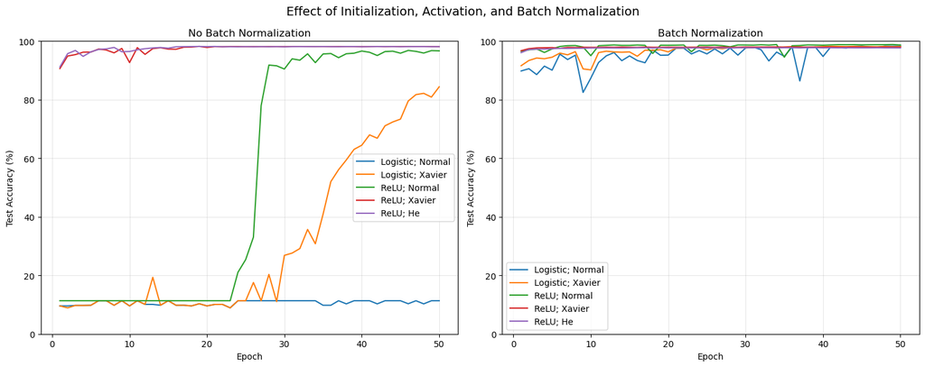

```python
epochs = range(1, 51)

fig, axes = plt.subplots(1, 2, figsize=(15, 6))

for name in deep_results_no_bn:
    axes[0].plot(
        epochs,
        deep_results_no_bn[name],
        label=name
    )

axes[0].set_title("No Batch Normalization")
axes[0].set_xlabel("Epoch")
axes[0].set_ylabel("Test Accuracy (%)")
axes[0].set_ylim(0, 100)
axes[0].grid(True, alpha=0.3)
axes[0].legend()

for name in deep_results_bn:
    axes[1].plot(
        epochs,
        deep_results_bn[name],
        label=name
    )

axes[1].set_title("Batch Normalization")
axes[1].set_xlabel("Epoch")
axes[1].set_ylabel("Test Accuracy (%)")
axes[1].set_ylim(0, 100)
axes[1].grid(True, alpha=0.3)
axes[1].legend()

fig.suptitle(
    "Effect of Initialization, Activation, and Batch Normalization",
    fontsize=14
)

plt.tight_layout()
plt.show()
```

As you can see, without batch normalization the activation function and initialization method have a pretty strong effeect on convergence. With batch normalization, the five configurations all become much more stable and their accuracies become more similar. This goes to show that batch normalization reduces the sensitivity to initialization adn activation choice significantly.